# Project Classification in R - module 1: Data_analysis

Jakub Tomczak

2026-05-13

# **Car Insurance Claims Prediction**

The project concerns the prediction of insurance claims reported in relation to various vehicles covered by insurance policies.

The data comes from Kaggle from a dataset called *Insurance Claims Dataset*, https://www.kaggle.com/datasets/litvinenko630/insurance-claims. This dataset contains nearly 60,000 observations, each observation refers to a single policy and contains detailed attributes related to the vehicle (such as engine power, fuel type, and the presence of various safety systems), as well as characteristics of the policy and the policyholder (such as policy duration, driver age, and region of residence).

The dataset addresses a key problem in the field of insurance risk assessment and fraud detection: predicting the likelihood of a claim being filed. Understanding which factors contribute to a higher likelihood of a claim allows insurance companies to price premiums more accurately, develop fairer risk models, and improve overall profitability. In addition, such predictive modeling can help insurers promote safer driving behaviors and identify high-risk policies early on.

**The aim of the project is to forecast insurance claims as accurately as possible using selected machine learning models.** Three models were selected:

- Random Forest
- XGBoost
- Ensembling of three models with the Stacking selection method.

The project has the following structure: data analysis and cleaning, then feature engineering and feature selection, followed by training each model and tuning hyperparameters, and finally testing the models on a test set and comparing the results. To this end, the project has been divided into 5 appropriate modules (R Markdown files) to increase its readability and simplify code handling.

## **1. Data cleaning and data analysis**

In this section, a preliminary analysis of the data (distribution of variables, correlations between them) will be performed, and the dataset will be cleaned of unnecessary variables and missing values. The dataset will also be adapted for further analysis—division into training and test sets (while maintaining reproducibility of research) and encoding of categorical variables.

```r
# loading all necessary libraries

library(here)
library(kableExtra)
library(rsample)
library(dplyr)
library(fastDummies)
library(ggcorrplot)
library(ggplot2)
source(here::here("new_project_r", "functions", "bar_plot_generator.R"))
```

```r
# Setting seed for reproducibility

set.seed(123)
```

#### Loading data and splitting it into train and test datasets

```r
data <- read.csv(here("data", "Insurance_claims_data.csv"))
```

```r
split <- initial_split(data, prop = 0.8)
data_train <- training(split)
data_test  <- testing(split)

cat("\nTRAIN:\n")
```

```
##
## TRAIN:
```

```r
kable(head(data_train))
```

| policy_id | subscription_length | vehicle_age | customer_age | region_code | region_density | segment | model | fuel_type | max_torque | max_power | engine_type | airbags | is_esc | is_adjustable_steering | is_tpms | is_parking_sensors | is_parking_camera | rear_brakes_type | displacement | cylinder | transmission_type | steering_type | turning_radius | length | width | gross_weight | is_front_fog_lights | is_rear_window_wiper | is_rear_window_washer | … |
| --- | --- | --- | --- | --- | --- | --- | --- | --- | --- | --- | --- | --- | --- | --- | --- | --- | --- | --- | --- | --- | --- | --- | --- | --- | --- | --- | --- | --- | --- | --- |
| POL014942 | 5.2 | 1.6 | 53 | C9 | 17804 | A | M3 | Petrol | 91Nm@4250rpm | 67.06bhp@5500rpm | 1.0 SCe | 2 | No | No | No | No | Yes | Drum | 999 | 3 | Automatic | Electric | 5.00 | 3731 | 1579 | 1155 | No | No | No | … |
| POL047582 | 3.5 | 1.8 | 52 | C11 | 6108 | B2 | M7 | Petrol | 113Nm@4400rpm | 88.50bhp@6000rpm | 1.2 L K Series Engine | 6 | Yes | Yes | No | Yes | Yes | Drum | 1197 | 4 | Automatic | Electric | 4.85 | 3990 | 1745 | 1410 | Yes | Yes | Yes | … |
| POL019270 | 5.1 | 1.4 | 41 | C12 | 34791 | B2 | M6 | Petrol | 113Nm@4400rpm | 88.50bhp@6000rpm | K Series Dual jet | 2 | No | Yes | No | Yes | No | Drum | 1197 | 4 | Manual | Electric | 4.80 | 3845 | 1735 | 1335 | Yes | No | No | … |
| POL013776 | 8.3 | 2.6 | 48 | C15 | 290 | B2 | M6 | Petrol | 113Nm@4400rpm | 88.50bhp@6000rpm | K Series Dual jet | 2 | No | Yes | No | Yes | No | Drum | 1197 | 4 | Manual | Electric | 4.80 | 3845 | 1735 | 1335 | Yes | No | No | … |
| POL016754 | 5.4 | 0.6 | 39 | C9 | 17804 | A | M1 | CNG | 60Nm@3500rpm | 40.36bhp@6000rpm | F8D Petrol Engine | 2 | No | No | No | Yes | No | Drum | 796 | 3 | Manual | Power | 4.60 | 3445 | 1515 | 1185 | No | No | No | … |
| POL003769 | 2.2 | 1.0 | 48 | C1 | 4990 | C2 | M4 | Diesel | 250Nm@2750rpm | 113.45bhp@4000rpm | 1.5 L U2 CRDi | 6 | Yes | Yes | Yes | Yes | Yes | Disc | 1493 | 4 | Automatic | Power | 5.20 | 4300 | 1790 | 1720 | Yes | Yes | Yes | … |

```r
cat("SHAPE:", paste(dim(data_train), collapse = " "))
```

```
## SHAPE: 46873 41
```

```r
cat("\n\nTEST:\n")
```

```
##
##
## TEST:
```

```r
kable(head(data_test))
```

| policy_id | subscription_length | vehicle_age | customer_age | region_code | region_density | segment | model | fuel_type | max_torque | max_power | engine_type | airbags | is_esc | is_adjustable_steering | is_tpms | is_parking_sensors | is_parking_camera | rear_brakes_type | displacement | cylinder | transmission_type | steering_type | turning_radius | length | width | gross_weight | is_front_fog_lights | is_rear_window_wiper | is_rear_window_washer | … |
| --- | --- | --- | --- | --- | --- | --- | --- | --- | --- | --- | --- | --- | --- | --- | --- | --- | --- | --- | --- | --- | --- | --- | --- | --- | --- | --- | --- | --- | --- | --- |
| POL045360 | 9.3 | 1.2 | 41 | C8 | 8794 | C2 | M4 | Diesel | 250Nm@2750rpm | 113.45bhp@4000rpm | 1.5 L U2 CRDi | 6 | Yes | Yes | Yes | Yes | Yes | Disc | 1493 | 4 | Automatic | Power | 5.2 | 4300 | 1790 | 1720 | Yes | Yes | Yes | … |
| POL018146 | 5.2 | 0.4 | 44 | C10 | 73430 | A | M1 | CNG | 60Nm@3500rpm | 40.36bhp@6000rpm | F8D Petrol Engine | 2 | No | No | No | Yes | No | Drum | 796 | 3 | Manual | Power | 4.6 | 3445 | 1515 | 1185 | No | No | No | … |
| POL050280 | 10.2 | 1.6 | 41 | C2 | 27003 | C2 | M4 | Diesel | 250Nm@2750rpm | 113.45bhp@4000rpm | 1.5 L U2 CRDi | 6 | Yes | Yes | Yes | Yes | Yes | Disc | 1493 | 4 | Automatic | Power | 5.2 | 4300 | 1790 | 1720 | Yes | Yes | Yes | … |
| POL002844 | 1.4 | 0.0 | 44 | C2 | 27003 | A | M1 | CNG | 60Nm@3500rpm | 40.36bhp@6000rpm | F8D Petrol Engine | 2 | No | No | No | Yes | No | Drum | 796 | 3 | Manual | Power | 4.6 | 3445 | 1515 | 1185 | No | No | No | … |
| POL016746 | 5.6 | 0.2 | 36 | C3 | 4076 | A | M1 | CNG | 60Nm@3500rpm | 40.36bhp@6000rpm | F8D Petrol Engine | 2 | No | No | No | Yes | No | Drum | 796 | 3 | Manual | Power | 4.6 | 3445 | 1515 | 1185 | No | No | No | … |
| POL002953 | 9.7 | 1.0 | 43 | C15 | 290 | A | M3 | Petrol | 91Nm@4250rpm | 67.06bhp@5500rpm | 1.0 SCe | 2 | No | No | No | No | Yes | Drum | 999 | 3 | Automatic | Electric | 5.0 | 3731 | 1579 | 1155 | No | No | No | … |

```r
cat("SHAPE:", paste(dim(data_test), collapse = " "))
```

```
## SHAPE: 11719 41
```

#### Data cleaning

```r
str(data_train)
```

```
## 'data.frame':    46873 obs. of  41 variables:
##  $ policy_id                       : chr  "POL014942" "POL047582" "POL019270" "POL013776" ...
##  $ subscription_length             : num  5.2 3.5 5.1 8.3 5.4 2.2 12 10.3 11.7 2.1 ...
##  $ vehicle_age                     : num  1.6 1.8 1.4 2.6 0.6 1 2 2 2.4 0.2 ...
##  $ customer_age                    : int  53 52 41 48 39 48 48 40 43 37 ...
##  $ region_code                     : chr  "C9" "C11" "C12" "C15" ...
##  $ region_density                  : int  17804 6108 34791 290 17804 4990 34738 8794 7788 4076 ...
##  $ segment                         : chr  "A" "B2" "B2" "B2" ...
##  $ model                           : chr  "M3" "M7" "M6" "M6" ...
##  $ fuel_type                       : chr  "Petrol" "Petrol" "Petrol" "Petrol" ...
##  $ max_torque                      : chr  "91Nm@4250rpm" "113Nm@4400rpm" "113Nm@4400rpm" "113Nm@4400rpm" ...
##  $ max_power                       : chr  "67.06bhp@5500rpm" "88.50bhp@6000rpm" "88.50bhp@6000rpm" "88.50bhp@6000rpm" ...
##  $ engine_type                     : chr  "1.0 SCe" "1.2 L K Series Engine" "K Series Dual jet" "K Series Dual jet" ...
##  $ airbags                         : int  2 6 2 2 2 6 6 2 2 2 ...
##  $ is_esc                          : chr  "No" "Yes" "No" "No" ...
```

[output cut: 27 more lines]

Checking for missing values

```r
missing_stats <- colMeans(is.na(data_train)) * 100
print(missing_stats)
```

```
##                        policy_id              subscription_length
##                                0                                0
##                      vehicle_age                     customer_age
##                                0                                0
##                      region_code                   region_density
##                                0                                0
##                          segment                            model
##                                0                                0
##                        fuel_type                       max_torque
##                                0                                0
##                        max_power                      engine_type
##                                0                                0
##                          airbags                           is_esc
##                                0                                0
##           is_adjustable_steering                          is_tpms
##                                0                                0
##               is_parking_sensors                is_parking_camera
##                                0                                0
##                 rear_brakes_type                     displacement
##                                0                                0
##                         cylinder                transmission_type
##                                0                                0
##                    steering_type                   turning_radius
##                                0                                0
##                           length                            width
##                                0                                0
##                     gross_weight              is_front_fog_lights
##                                0                                0
##             is_rear_window_wiper            is_rear_window_washer
##                                0                                0
##          is_rear_window_defogger                  is_brake_assist
##                                0                                0
##              is_power_door_locks               is_central_locking
##                                0                                0
##                is_power_steering is_driver_seat_height_adjustable
##                                0                                0
##    is_day_night_rear_view_mirror                           is_ecw
##                                0                                0
##                   is_speed_alert                      ncap_rating
##                                0                                0
##                     claim_status
##                                0
```

##### **We want to deleate not significant features like policy_id which has different value for each observation, so it doesn’t add any more information to the dataset**

```r
features_to_remove <- c("policy_id", "region_code", "engine_type")
data_train <- data_train %>% select(-all_of(features_to_remove))
data_test  <- data_test  %>% select(-all_of(features_to_remove))
```

#### **Encoding object type variables:**

For that we use one hot encoding

```r
data_new <- data_train
data_test_new <- data_test

# 2. One-Hot Encoding for train set

data_new <- dummy_cols(data_new,
                     remove_selected_columns = TRUE,
                     ignore_na = TRUE)

cat("Frequency of data type (TRAIN):\n")
```

```
## Frequency of data type (TRAIN):
```

```r
print(table(sapply(data_new, class)))
```

```
##
## integer numeric
##      89       3
```

```r
# 3. One-Hot Encoding for test set
data_test_new <- dummy_cols(data_test_new,
                          remove_selected_columns = TRUE,
                          ignore_na = TRUE)

cat("\nFrequency of data type (TEST):\n")
```

```
##
## Frequency of data type (TEST):
```

```r
print(table(sapply(data_test_new, class)))
```

```
##
## integer numeric
##      89       3
```

### Data analysis

#### **Distribution of target variable**

```r
data_new %>% count(claim_status)
```

```
##   claim_status     n
## 1            0 43934
## 2            1  2939
```

Our data set is therefore highly unbalanced, as positive claims account for only 6% of all claims.

#### **Basic data statistics and corelations between continous variables**

```r
data_continous <- data_train %>% select(where(is.numeric))

summary(data_continous)
```

```
##  subscription_length  vehicle_age      customer_age   region_density
##  Min.   : 0.000      Min.   : 0.000   Min.   :35.00   Min.   :  290
##  1st Qu.: 2.100      1st Qu.: 0.400   1st Qu.:40.00   1st Qu.: 6112
##  Median : 5.700      Median : 1.200   Median :44.00   Median : 8794
##  Mean   : 6.103      Mean   : 1.388   Mean   :44.82   Mean   :18824
##  3rd Qu.:10.400      3rd Qu.: 2.200   3rd Qu.:49.00   3rd Qu.:27003
##  Max.   :13.900      Max.   :20.000   Max.   :75.00   Max.   :73430
##     airbags       displacement     cylinder     turning_radius      length
##  Min.   :1.000   Min.   : 796   Min.   :3.000   Min.   :4.500   Min.   :3445
##  1st Qu.:2.000   1st Qu.: 796   1st Qu.:3.000   1st Qu.:4.600   1st Qu.:3445
##  Median :2.000   Median :1197   Median :4.000   Median :4.800   Median :3845
##  Mean   :3.138   Mean   :1163   Mean   :3.626   Mean   :4.853   Mean   :3851
##  3rd Qu.:6.000   3rd Qu.:1493   3rd Qu.:4.000   3rd Qu.:5.000   3rd Qu.:3995
##  Max.   :6.000   Max.   :1498   Max.   :4.000   Max.   :5.200   Max.   :4300
##      width       gross_weight   ncap_rating     claim_status
##  Min.   :1475   Min.   :1051   Min.   :0.000   Min.   :0.0000
##  1st Qu.:1515   1st Qu.:1185   1st Qu.:0.000   1st Qu.:0.0000
##  Median :1735   Median :1335   Median :2.000   Median :0.0000
##  Mean   :1672   Mean   :1386   Mean   :1.767   Mean   :0.0627
##  3rd Qu.:1755   3rd Qu.:1510   3rd Qu.:3.000   3rd Qu.:0.0000
##  Max.   :1811   Max.   :1720   Max.   :5.000   Max.   :1.0000
```

```r
# Creating corelation matrix
corr_matrix <- cor(data_continous, method = "spearman")

foo <- as.data.frame(as.table(corr_matrix)) %>%
  rename(Var1 = Var1, Var2 = Var2, corr_val = Freq) %>%

  filter(as.character(Var1) < as.character(Var2)) %>%
  mutate(abs_corr = abs(corr_val)) %>%
  arrange(desc(abs_corr))


head(foo, 10)
```

```
##              Var1           Var2  corr_val  abs_corr
## 1    displacement         length 0.9532824 0.9532824
## 2          length          width 0.9457183 0.9457183
## 3          length turning_radius 0.9427221 0.9427221
## 4  turning_radius          width 0.9242677 0.9242677
## 5    displacement    ncap_rating 0.9124863 0.9124863
## 6    displacement turning_radius 0.8983193 0.8983193
## 7    displacement          width 0.8769251 0.8769251
## 8     ncap_rating turning_radius 0.8562754 0.8562754
## 9        cylinder   displacement 0.8480846 0.8480846
## 10         length    ncap_rating 0.8417249 0.8417249
```

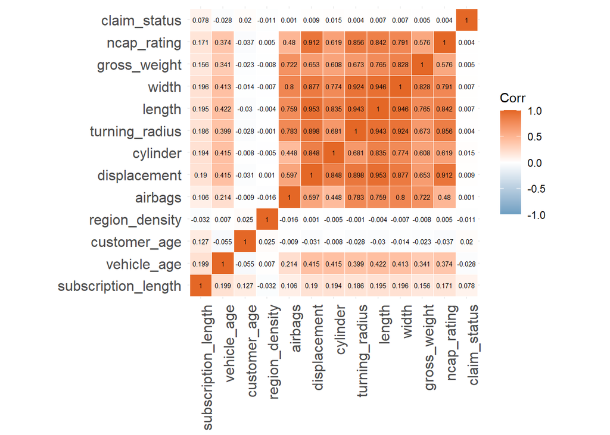

```r
# Plot creation
p <- ggcorrplot(
  corr_matrix,
  hc.order = FALSE,
  type = "full",
  lab = TRUE,
  lab_size = 2,
  digits = 3,
  outline.color = "white",
  colors = c("#6D9EC1", "white", "#E46726")
) +
  theme(axis.text.x = element_text(size = 12, angle = 90),
        axis.text.y = element_text(size = 12))
# 3. Plot display
print(p)
```

Some continuous variables are strongly correlated with each other, while there is virtually no correlation between certain variables.

```r
# Saving plot
plot_path <- here("new_project_r", "plots", "correlation_heatmap_plot.png")

ggsave(
  filename = plot_path,
  plot = p,
  width = 15,
  height = 15,
  dpi = 300
)
```

#### **Distributions of some of categorical variables (before encoding)**

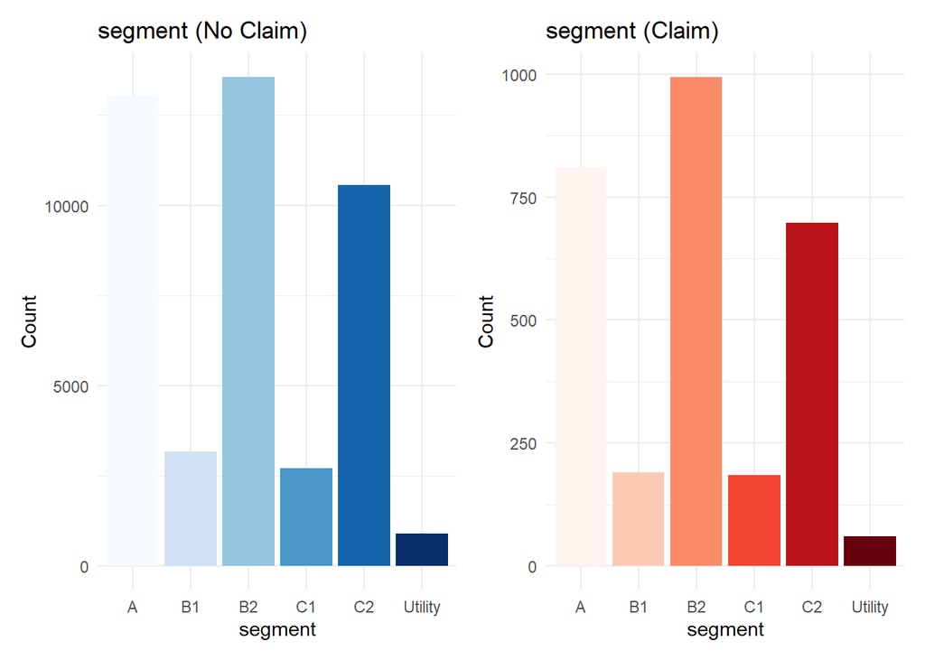

```r
segment_plot <- bar_plot_generator(data_train, "segment")
```

```r
# Saving plot
plot_path <- here("new_project_r", "plots", "segment_barplot.png")

ggsave(
  filename = plot_path,
  plot = segment_plot,
  width = 15,
  height = 15,
  dpi = 300
)
```

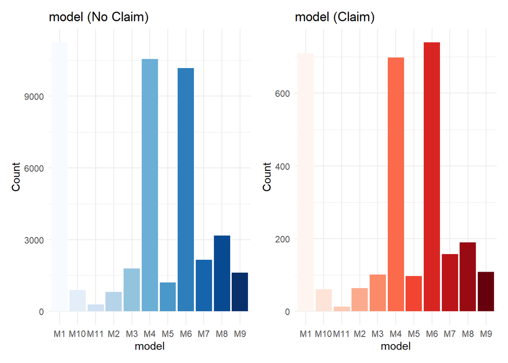

```r
model_plot <- bar_plot_generator(data_train, "model")
```

```r
# Saving plot
plot_path <- here("new_project_r", "plots", "model_barplot.png")

ggsave(
  filename = plot_path,
  plot = model_plot,
  width = 15,
  height = 15,
  dpi = 300
)
```

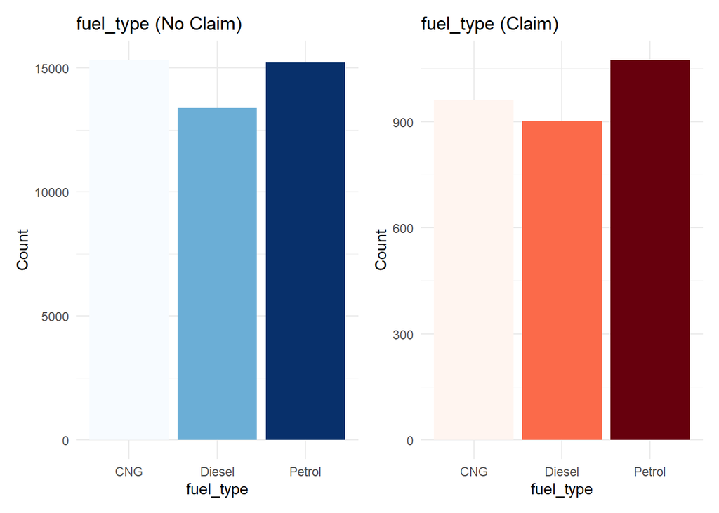

```r
fuel_type_plot <- bar_plot_generator(data_train, "fuel_type")
```

```r
# Saving plot
plot_path <- here("new_project_r", "plots", "fuel_type_barplot.png")

ggsave(
  filename = plot_path,
  plot = fuel_type_plot,
  width = 15,
  height = 15,
  dpi = 300
)
```

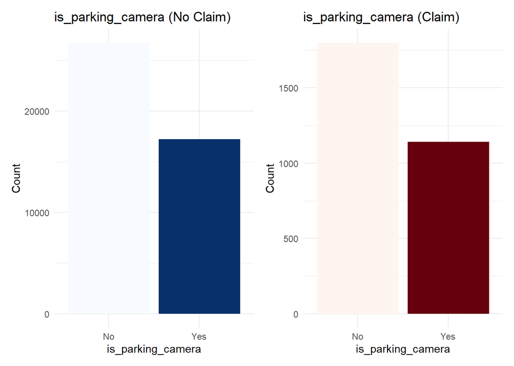

```r
is_parking_camera_plot <- bar_plot_generator(data_train, "is_parking_camera")
```

```r
# Saving plot
plot_path <- here("new_project_r", "plots", "is_parking_camera_barplot.png")

ggsave(
  filename = plot_path,
  plot = is_parking_camera_plot,
  width = 15,
  height = 15,
  dpi = 300
)
```

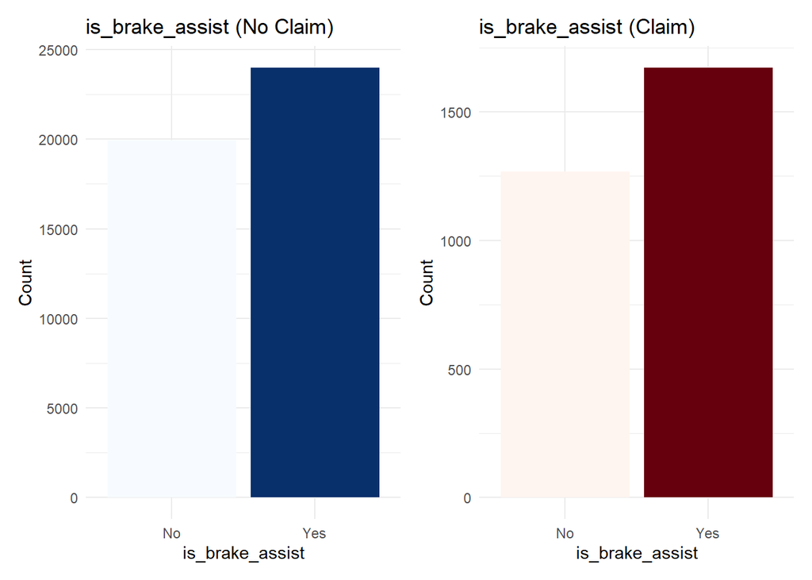

```r
is_brake_assist_plot <- bar_plot_generator(data_train, "is_brake_assist")
```

```r
# Saving plot
plot_path <- here("new_project_r", "plots", "is_brake_assist_barplot.png")

ggsave(
  filename = plot_path,
  plot = is_brake_assist_plot,
  width = 15,
  height = 15,
  dpi = 300
)
```

### **Saving cleand train and test datasets**

```r
write.csv(data_new, here("data", "data_cleaned.csv"), row.names = FALSE)
```

```r
write.csv(data_test_new, here("data", "data_test_cleaned.csv"), row.names = FALSE)
```